# Analysis of Fatalities, injuries and damage caused by severe weather events

## Severe weather events that cause the largest amount of damage

Add a field with a total of all damage, both to property as well as to crop, so that we can find our what events cause the highest amount of damage. The new column is called damage. The column is in billions of dollars.

```r
smallData$damage = ((smallData$propertydamage + smallData$cropdamage)/1e+09)
```

We create a new set with the aggregate of the damage grouped by the event types.

```r
damageData <- aggregate(list(damage = smallData$damage), by = list(event = smallData$category),
    FUN = sum, na.rm = TRUE)
```

Here is the overview of the event categories with the amount of damage

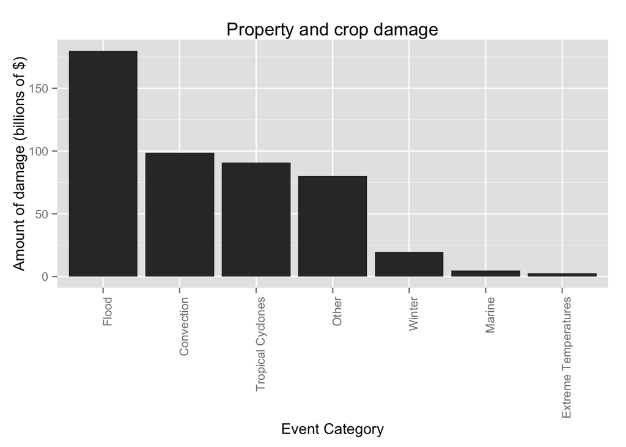

```r
damageData$event <- reorder(damageData$event, -damageData$damage)
ggplot(damageData, aes(y = damage)) + theme(axis.text.x = element_text(angle = 90,
    hjust = 1)) + geom_bar(aes(x = event), data = damageData, stat = "identity") +
    ggtitle("Property and crop damage") + xlab("Event Category") + ylab("Amount of damage (billions of $)")
```

Clearly the flooding events (Flash Flood, River Flood) have the greatest effect on property damage and crop damage.

After Converting the data into an aggregate form and replacing state abbreviations with their name, I built a new csv containing the aggregate data and removed the states that were not present in the maps package

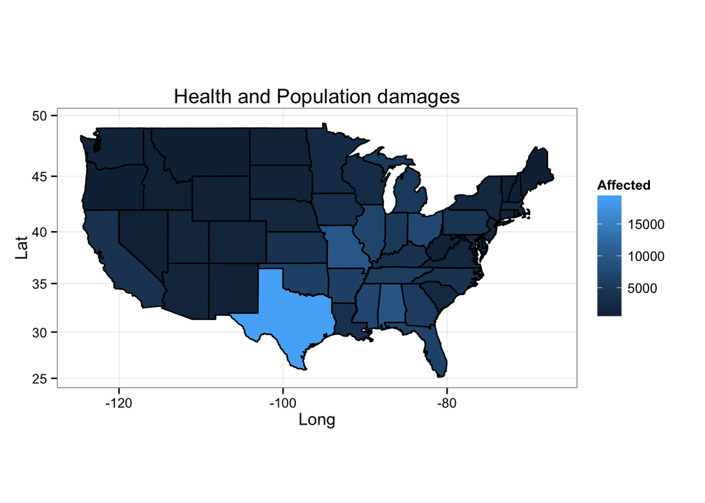

```r
states_map <- map_data("state")
data<-read.csv('events.agg.csv')
aggdata<-aggregate(data[,c('FATALITIES','INJURIES','PROPDMG','CROPDMG')],by=list(data$STATE),FUN=sum)
aggdata$Affected = aggdata$FATALITIES+aggdata$INJURIES
colnames(aggdata)<-c("STATE","FATALITIES","INJURIES","PROPDMG","CROPDMG","Affected")
aggdata$STATE<-as.character(aggdata$STATE)
p <- ggplot(aggdata, aes(map_id = STATE))
p <- p + geom_map(aes(fill = Affected), map = states_map, colour='black') + expand_limits(x = states_map$long, y = states_map$lat)
p <- p + coord_map() + theme_bw()
p <- p + labs(x = "Long", y = "Lat", title = "Health and Population damages")
print(p)
```

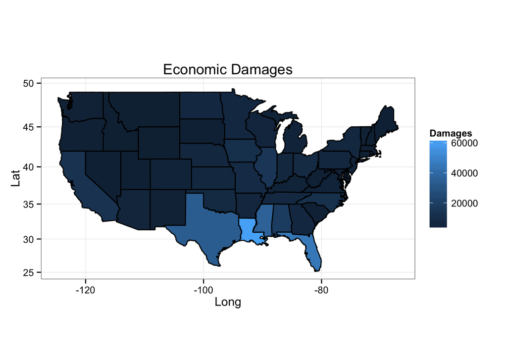

```r
aggdata$Damages<-aggdata$CROPDMG+aggdata$PROPDMG
p <- ggplot(aggdata, aes(map_id = STATE))
p <- p + geom_map(aes(fill = Damages), map = states_map, colour='black') + expand_limits(x = states_map$long, y = states_map$lat)
p <- p + coord_map() + theme_bw()
p <- p + labs(x = "Long", y = "Lat", title = "Economic Damages")
print(p)
```

## Reflections

- There were many challenges in this project particularly due to the fact that there was so much cleaning up to do in order to get the data ready to be analysed. I believe, I may have ballparked a few data, however My initial EDA conforms to the final conclusion which I have given.
- A particular point about this dataset is that it contains many events which do not contribute to much damages which lead to a large redundancy of data.
- As far as the imporvement in analysis is concerned, I believe a few more correlations between the features at stake would go onto provide more insights into the data set.
- My Analysis has been that in terms of a broad sense. A few more intricate details can be covered within this data set leading to better results and conclusion from the data.
- Features are less due to the fact that a large number of values are noth fathomable and have averaged ot value.